# **統深作業五**

### B09303047 林奕霆

```python
%matplotlib inline
import pickle
from google.colab import drive
drive.mount('/content/drive')
from sklearn import preprocessing
import numpy as np
import sklearn.metrics as metrics
```

## 第一題

```python
import matplotlib.pyplot as plt
from PIL import Image
import os
import glob
import random

labels = ['blazer', 'cardigan', 'coat', 'jacket']
dataset = ['train', 'valid', 'test']
unit_count = {i: 0 for i in labels}
counts = {j: unit_count for j in dataset}
print(counts)
k = 0

for i in dataset:
  for j in labels:
    file = glob.glob(os.path.join('/content/drive/MyDrive/photos/'+i,j, "*.jpg"))
    counts[i][j] += len(file)
  dataset_count = sum(counts[i].values())
  print(f'{dataset[k]} : {dataset_count} 張圖片')
  k+=1
  for j in labels:
    label_count = counts[i][j]
    print(f'~~~{j} : {label_count} 張圖片 {label_count/dataset_count*100:.2f}%')
```

```
{'train': {'blazer': 0, 'cardigan': 0, 'coat': 0, 'jacket': 0}, 'valid': {'blazer': 0, 'cardigan': 0, 'coat': 0, 'jacket': 0}, 'test': {'blazer': 0, 'cardigan': 0, 'coat': 0, 'jacket': 0}}
train : 1041 張圖片
~~~blazer : 97 張圖片 9.32%
~~~cardigan : 237 張圖片 22.77%
~~~coat : 296 張圖片 28.43%
~~~jacket : 411 張圖片 39.48%
valid : 1146 張圖片
~~~blazer : 104 張圖片 9.08%
~~~cardigan : 273 張圖片 23.82%
~~~coat : 323 張圖片 28.18%
~~~jacket : 446 張圖片 38.92%
test : 1292 張圖片
~~~blazer : 113 張圖片 8.75%
~~~cardigan : 315 張圖片 24.38%
~~~coat : 366 張圖片 28.33%
~~~jacket : 498 張圖片 38.54%
```

因為在各個dataset中，jacket的比例皆占最多而blazer佔最少比例，因此推斷模型在訓練過程中能學到更多有關jacket的資訊，而blazer可能則相對較少。

推斷jacket判斷準確率可能較高，coat次之，blazer最低。

## 第二題

```python
# Early Stopping的Patient參數設為20 Epochs。Batch size設為32。每一個Epoch計算一次Valid Loss，並記錄Valid Loss最低的模型。模型訓練最多200個Epochs。
import torch
import torch.nn.functional as F
from torch.utils.data import Dataset, DataLoader
from torchvision import datasets, transforms, models
import torch.optim as optim
```

```python
# preprocessing
# 由於圖片的解析度較高，模型訓練前須將解析度調整(Resize)成較短邊為256像素的照片，然後隨機取大小為224x224的影像。接著隨機水平翻轉(Horizontal Flip)、隨機旋轉-20度到20度，並依照Pretrained ResNet的要求調整RGB的均數與標準差。
# 測試資料(Valid and Test)亦須先將解析度調整(Resize)成較短邊為256像素的照片，然後取圖片中心224x224的影像。

preprocess_train = transforms.Compose([transforms.Resize(256),
    transforms.RandomCrop(224),
    transforms.RandomHorizontalFlip(),
    transforms.RandomRotation(20),
    transforms.ToTensor(),
    transforms.Normalize(mean=[0.485, 0.456, 0.406], std=[0.229, 0.224, 0.225]),      ])

preprocess_test = transforms.Compose([transforms.Resize(256),
    transforms.CenterCrop(224),
    transforms.ToTensor(),
    transforms.Normalize(mean=[0.485, 0.456, 0.406], std=[0.229, 0.224, 0.225])])

train_dataset = datasets.ImageFolder(root='/content/drive/MyDrive/photos/train', transform=preprocess_train)
valid_dataset = datasets.ImageFolder(root='/content/drive/MyDrive/photos/valid', transform=preprocess_test)
test_dataset  = datasets.ImageFolder(root='/content/drive/MyDrive/photos/test',  transform=preprocess_test)

train_loader = DataLoader(train_dataset, batch_size=32, shuffle=True)
valid_loader = DataLoader(valid_dataset, batch_size=32, shuffle=False)
test_loader  = DataLoader(test_dataset,  batch_size=1,  shuffle=False)
```

```python
import torch.nn as nn

class myresnet():
  def __init__(self):
    self.loss_func = nn.CrossEntropyLoss()
    self.valid_loss = []
    self.valid_accuracy = []
  def evaluate(self, model, data_loader):
    total_loss = 0
    total_correct = 0
    total_count = 0
    model.eval()
    with torch.no_grad():
      for inputs, labels in data_loader:
        outputs = model(inputs)
        total_loss += self.loss_func(outputs, labels)*labels.shape[0]
        total_count += len(outputs)
        x, preds = torch.max(outputs, dim=1)
        total_correct += torch.sum(preds == labels).item()
    model.train()
    loss_ratio = total_loss/total_count
    correct_ratio = total_correct/total_count
    return loss_ratio, correct_ratio
  def fit(self, model, train_loader, valid_loader, optimizer, epoch):
    best_model = model
    # 計算初始殘差
    valid_loss2, valid_accuracy2 = self.evaluate(model, valid_loader)
    self.valid_loss.append(valid_loss2)
    self.valid_accuracy.append(valid_accuracy2)

    top_epoch = 0
    top_loss = 10
    for i in range(epoch):
      # train the model
      for batch in train_loader:
        inputs, labels = batch
        optimizer.zero_grad()
        output = model(inputs)
        loss = self.loss_func(output, labels)
        loss.backward()
        optimizer.step()

      valid_loss2, valid_accuracy2 = self.evaluate(model, valid_loader)
      self.valid_loss.append(valid_loss2)
      self.valid_accuracy.append(valid_accuracy2)
      print(f'epoch{i}')
      print(valid_loss2, top_loss)
      if valid_loss2 < top_loss:
        top_epoch = i
        top_loss = valid_loss2
        best_model = model #
      if i - top_epoch >= 20:
        return best_model, self.valid_accuracy, self.valid_loss
    return best_model, self.valid_accuracy, self.valid_loss

  def test(self, model, data_loader):
    correct_sum = 0
    total_count = 0
    model.eval()
    y_pred = []
    y_expected = []
    with torch.no_grad():
      for inputs, labels in data_loader:
        outputs = model(inputs)
        total_count += len(outputs)
        x, preds = torch.max(outputs, dim=1)

        y_pred.append(preds.item())
        y_expected.append(labels.item())
        correct_sum += torch.sum(preds == labels).item()
    accuracy = correct_sum/total_count
    print(f'Test Accuracy: {100*accuracy:.2f}%')

    # confusion matrix
    confusion_matrix = metrics.confusion_matrix(y_true=y_expected, y_pred = y_pred)
    cm_display = metrics.ConfusionMatrixDisplay(confusion_matrix = confusion_matrix, display_labels = ['blazer', 'cardigan', 'coat', 'jacket'])
    cm_display.plot(cmap=plt.cm.Oranges)
    plt.title('confusion matrix')
    plt.show()
    return confusion_matrix
```

```python
# 使用torchvision提供的pretrained weights初始化模型權重
resmodel = models.resnet50(pretrained=True)
resmodel.func = nn.Linear(resmodel.fc.in_features, len(train_dataset.classes))
epoch = 200
optimizer = torch.optim.SGD(resmodel.parameters(), lr = 0.0004, momentum=0.8)
myresnet = myresnet()
model, accuracy_, loss_ = myresnet.fit(resmodel, train_loader, valid_loader, optimizer, epoch)
```

```
epoch0
tensor(2.6762) 10
epoch1
tensor(1.5991) tensor(2.6762)
epoch2
tensor(1.2902) tensor(1.5991)
epoch3
tensor(1.1364) tensor(1.2902)
epoch4
tensor(1.0857) tensor(1.1364)
epoch5
tensor(1.0372) tensor(1.0857)
epoch6
tensor(0.9808) tensor(1.0372)
epoch7
tensor(0.8920) tensor(0.9808)
epoch8
tensor(0.8493) tensor(0.8920)
epoch9
tensor(0.8490) tensor(0.8493)
epoch10
tensor(0.8118) tensor(0.8490)
epoch11
tensor(0.8114) tensor(0.8118)
epoch12
tensor(0.8020) tensor(0.8114)
epoch13
tensor(0.7306) tensor(0.8020)
epoch14
tensor(0.7505) tensor(0.7306)
epoch15
tensor(0.7388) tensor(0.7306)
epoch16
tensor(0.7089) tensor(0.7306)
epoch17
tensor(0.7064) tensor(0.7089)
epoch18
tensor(0.6843) tensor(0.7064)
epoch19
tensor(0.6708) tensor(0.6843)
```

[output cut: 45 more lines]

```
tensor(0.6951) tensor(0.6510)
epoch43
tensor(0.7191) tensor(0.6510)
epoch44
tensor(0.6781) tensor(0.6510)
epoch45
tensor(0.6984) tensor(0.6510)
epoch46
tensor(0.7154) tensor(0.6510)
epoch47
tensor(0.6812) tensor(0.6510)
epoch48
tensor(0.7087) tensor(0.6510)
epoch49
tensor(0.7268) tensor(0.6510)
```

```python
epochlist = list(range(1,len(loss_)+1))
for i in range(len(epochlist)):
  print(f'{epochlist[i]} : loss={loss_[i]}')
```

```
1 : loss=14.469093322753906
2 : loss=2.6762187480926514
3 : loss=1.5990943908691406
4 : loss=1.2901595830917358
5 : loss=1.1364041566848755
6 : loss=1.0857280492782593
7 : loss=1.037169337272644
8 : loss=0.9808287024497986
9 : loss=0.8919903635978699
10 : loss=0.8493039011955261
11 : loss=0.8490442037582397
12 : loss=0.8117780685424805
13 : loss=0.8113715052604675
14 : loss=0.8019585609436035
15 : loss=0.7306299805641174
```

[output cut: 36 more lines]

輸出SGD testing set 預測結果

```
Test Accuracy: 78.08%
```

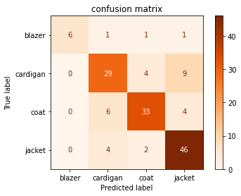

```python
matrix = myresnet.test(model, test_loader)
```

```python
# 印出每個類別的準確度
matrix = list(matrix)
for i in range(4):
  print(f'{test_dataset.classes[i]}: accuracy={matrix[i][i]/sum(matrix[i])*100:.2f}%')
```

```
blazer: accuracy=66.67%
cardigan: accuracy=69.05%
coat: accuracy=76.74%
jacket: accuracy=88.46%
```

```python
# 使用torchvision提供的pretrained weights初始化模型權重
resmodel2 = models.resnet50(pretrained=True)
resmodel2.func = nn.Linear(resmodel2.fc.in_features, len(train_dataset.classes))
epoch = 200
optimizer = torch.optim.Adam(resmodel2.parameters(), lr = 0.000025)
model2, accuracy_, loss_ = myresnet.fit(resmodel2, train_loader, valid_loader, optimizer, epoch)
```

```
epoch0
tensor(6.4520) 10
epoch1
tensor(2.7805) tensor(6.4520)
epoch2
tensor(1.7145) tensor(2.7805)
epoch3
tensor(1.2778) tensor(1.7145)
epoch4
tensor(0.8743) tensor(1.2778)
epoch5
tensor(0.7677) tensor(0.8743)
epoch6
tensor(0.7649) tensor(0.7677)
epoch7
tensor(0.7076) tensor(0.7649)
epoch8
tensor(0.7558) tensor(0.7076)
epoch9
tensor(0.7218) tensor(0.7076)
epoch10
tensor(0.6830) tensor(0.7076)
epoch11
tensor(0.8239) tensor(0.6830)
epoch12
tensor(0.7077) tensor(0.6830)
epoch13
tensor(0.7465) tensor(0.6830)
epoch14
tensor(0.7539) tensor(0.6830)
epoch15
tensor(0.7036) tensor(0.6830)
epoch16
tensor(0.7596) tensor(0.6830)
epoch17
tensor(0.7163) tensor(0.6830)
epoch18
tensor(0.7156) tensor(0.6830)
epoch19
tensor(0.7012) tensor(0.6830)
```

[output cut: 33 more lines]

```
tensor(0.8939) tensor(0.6192)
epoch37
tensor(0.8299) tensor(0.6192)
epoch38
tensor(0.8223) tensor(0.6192)
epoch39
tensor(0.8816) tensor(0.6192)
epoch40
tensor(0.8863) tensor(0.6192)
epoch41
tensor(0.9020) tensor(0.6192)
epoch42
tensor(0.9010) tensor(0.6192)
epoch43
tensor(0.9393) tensor(0.6192)
```

輸出ADAM testing set 預測結果

```
Test Accuracy: 78.77%
```

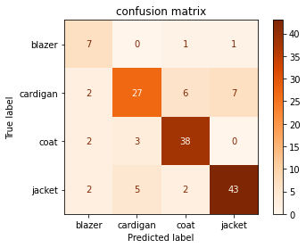

```
blazer: accuracy=77.78%
cardigan: accuracy=64.29%
coat: accuracy=88.37%
jacket: accuracy=82.69%
```

```python
matrix = myresnet.test(model2, test_loader)
# 印出每個類別的準確度
matrix = list(matrix)
for i in range(4):
  print(f'{test_dataset.classes[i]}: accuracy={matrix[i][i]/sum(matrix[i])*100:.2f}%')
```

## 第三題

```python
resmodel3 = models.resnet50(pretrained=True)
for param in resmodel3.parameters():
  param.requires_grad = False
resmodel3.fc = nn.Linear(resmodel3.fc.in_features, len(train_dataset.classes))
optimizer = optim.Adam(resmodel3.parameters(), lr = 0.00015)
model3, accuracy_, loss_ = myresnet.fit(resmodel3, train_loader, valid_loader, optimizer, epoch)
```

```
epoch0
tensor(1.2592) 10
epoch1
tensor(1.2286) tensor(1.2592)
epoch2
tensor(1.1857) tensor(1.2286)
epoch3
tensor(1.1505) tensor(1.1857)
epoch4
tensor(1.1608) tensor(1.1505)
epoch5
tensor(1.1599) tensor(1.1505)
epoch6
tensor(1.1314) tensor(1.1505)
epoch7
tensor(1.0937) tensor(1.1314)
epoch8
tensor(1.0904) tensor(1.0937)
epoch9
tensor(1.0518) tensor(1.0904)
epoch10
tensor(1.0579) tensor(1.0518)
epoch11
tensor(1.0582) tensor(1.0518)
epoch12
tensor(1.0415) tensor(1.0518)
epoch13
tensor(1.0062) tensor(1.0415)
epoch14
tensor(1.0253) tensor(1.0062)
epoch15
tensor(1.0257) tensor(1.0062)
epoch16
tensor(1.0154) tensor(1.0062)
epoch17
tensor(1.0277) tensor(1.0062)
epoch18
tensor(0.9904) tensor(1.0062)
epoch19
tensor(0.9902) tensor(0.9904)
```

[output cut: 97 more lines]

```
tensor(0.9506) tensor(0.9385)
epoch69
tensor(0.9541) tensor(0.9385)
epoch70
tensor(0.9473) tensor(0.9385)
epoch71
tensor(0.9507) tensor(0.9385)
epoch72
tensor(0.9483) tensor(0.9385)
epoch73
tensor(0.9567) tensor(0.9385)
epoch74
tensor(0.9464) tensor(0.9385)
epoch75
tensor(0.9519) tensor(0.9385)
```

**輸出只調整最後一層之Adam結果**

```
Test Accuracy: 60.27%
```

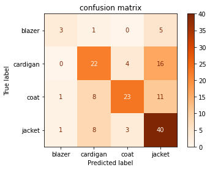

```
blazer: accuracy=33.33%
cardigan: accuracy=52.38%
coat: accuracy=53.49%
jacket: accuracy=76.92%
```

```python
matrix3 = myresnet.test(model3, test_loader)
# 印出每個類別的準確度
matrix = list(matrix3)
for i in range(4):
  print(f'{test_dataset.classes[i]}: accuracy={matrix[i][i]/sum(matrix[i])*100:.2f}%')
```

```python
# 使用torchvision提供的pretrained weights初始化模型權重
resmodel4 = models.resnet50(pretrained=True)
for param in resmodel4.parameters():
  param.requires_grad = False
epoch = 200

resmodel4.fc = nn.Linear(resmodel4.fc.in_features, len(train_dataset.classes))
optimizer = torch.optim.SGD(resmodel4.parameters(), lr = 0.0008,momentum=0.9)
model4, accuracy_, loss_ = myresnet.fit(resmodel4, train_loader, valid_loader, optimizer, epoch)
```

```
epoch0
tensor(1.2095) 10
epoch1
tensor(1.1415) tensor(1.2095)
epoch2
tensor(1.0833) tensor(1.1415)
epoch3
tensor(1.1220) tensor(1.0833)
epoch4
tensor(1.0551) tensor(1.0833)
epoch5
tensor(1.0209) tensor(1.0551)
epoch6
tensor(1.0072) tensor(1.0209)
epoch7
tensor(1.0480) tensor(1.0072)
epoch8
tensor(1.0659) tensor(1.0072)
epoch9
tensor(0.9756) tensor(1.0072)
epoch10
tensor(1.0015) tensor(0.9756)
epoch11
tensor(0.9779) tensor(0.9756)
epoch12
tensor(0.9745) tensor(0.9756)
epoch13
tensor(0.9837) tensor(0.9745)
epoch14
tensor(0.9539) tensor(0.9745)
epoch15
tensor(1.0125) tensor(0.9539)
epoch16
tensor(0.9658) tensor(0.9539)
epoch17
tensor(0.9552) tensor(0.9539)
epoch18
tensor(0.9908) tensor(0.9539)
epoch19
tensor(0.9446) tensor(0.9539)
```

[output cut: 39 more lines]

```
tensor(0.9491) tensor(0.9309)
epoch40
tensor(0.9322) tensor(0.9309)
epoch41
tensor(0.9373) tensor(0.9309)
epoch42
tensor(1.0085) tensor(0.9309)
epoch43
tensor(0.9463) tensor(0.9309)
epoch44
tensor(1.0081) tensor(0.9309)
epoch45
tensor(0.9734) tensor(0.9309)
epoch46
tensor(0.9863) tensor(0.9309)
```

**輸出只調整最後一層之SGD結果**

```
Test Accuracy: 63.70%
```

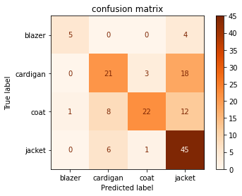

```
blazer: accuracy=55.56%
cardigan: accuracy=50.00%
coat: accuracy=51.16%
jacket: accuracy=86.54%
```

```python
matrix4 = myresnet.test(model4, test_loader)
# 印出每個類別的準確度
matrix = list(matrix4)
for i in range(4):
  print(f'{test_dataset.classes[i]}: accuracy={matrix[i][i]/sum(matrix[i])*100:.2f}%')
```

## 第四題

```python
# 使用torchvision提供的pretrained weights初始化模型權重
resmodel5 = models.resnet50(pretrained=False)
resmodel5.func = nn.Linear(resmodel5.fc.in_features, len(train_dataset.classes))
epoch = 200
optimizer = torch.optim.SGD(resmodel5.parameters(), lr = 0.00045, momentum=0.8)
model5, accuracy_, loss_ = myresnet.fit(resmodel5, train_loader, valid_loader, optimizer, epoch)
```

```
epoch0
tensor(1.5091) 10
epoch1
tensor(1.3810) tensor(1.5091)
epoch2
tensor(1.3016) tensor(1.3810)
epoch3
tensor(1.3273) tensor(1.3016)
epoch4
tensor(1.3183) tensor(1.3016)
epoch5
tensor(1.3299) tensor(1.3016)
epoch6
tensor(1.3929) tensor(1.3016)
epoch7
tensor(1.3402) tensor(1.3016)
epoch8
tensor(1.3318) tensor(1.3016)
epoch9
tensor(1.2714) tensor(1.3016)
epoch10
tensor(1.4636) tensor(1.2714)
epoch11
tensor(1.3560) tensor(1.2714)
epoch12
tensor(1.3387) tensor(1.2714)
epoch13
tensor(1.3049) tensor(1.2714)
epoch14
tensor(1.3116) tensor(1.2714)
epoch15
tensor(1.2850) tensor(1.2714)
epoch16
tensor(1.2742) tensor(1.2714)
epoch17
tensor(1.3639) tensor(1.2714)
epoch18
tensor(1.3020) tensor(1.2714)
epoch19
tensor(1.3297) tensor(1.2714)
epoch20
tensor(1.2952) tensor(1.2714)
epoch21
tensor(1.3305) tensor(1.2714)
epoch22
tensor(1.4030) tensor(1.2714)
epoch23
tensor(1.3630) tensor(1.2714)
epoch24
tensor(1.3672) tensor(1.2714)
epoch25
tensor(1.3877) tensor(1.2714)
epoch26
tensor(1.3116) tensor(1.2714)
epoch27
tensor(1.3865) tensor(1.2714)
epoch28
tensor(1.3139) tensor(1.2714)
epoch29
tensor(1.4272) tensor(1.2714)
```

**輸出沒經過pretrain的SGD測結果**

```
Test Accuracy: 35.62%
```

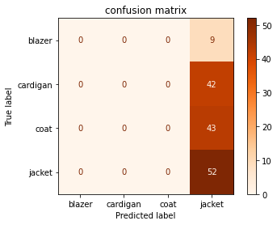

```
blazer: accuracy=0.00%
cardigan: accuracy=0.00%
coat: accuracy=0.00%
jacket: accuracy=100.00%
```

```python
matrix5 = myresnet.test(model5, test_loader)
# 印出每個類別的準確度
matrix = list(matrix5)
for i in range(4):
  print(f'{test_dataset.classes[i]}: accuracy={matrix[i][i]/sum(matrix[i])*100:.2f}%')
```

```python
# 使用torchvision提供的pretrained weights初始化模型權重
resmodel6 = models.resnet50(pretrained=False)
resmodel6.func = nn.Linear(resmodel6.fc.in_features, len(train_dataset.classes))
epoch = 200
optimizer = torch.optim.Adam(resmodel6.parameters(), lr = 0.000025)
model6, accuracy_, loss_ = myresnet.fit(resmodel6, train_loader, valid_loader, optimizer, epoch)
```

```
epoch0
tensor(4.5976) 10
epoch1
tensor(1.8444) tensor(4.5976)
epoch2
tensor(1.4272) tensor(1.8444)
epoch3
tensor(1.3835) tensor(1.4272)
epoch4
tensor(1.3950) tensor(1.3835)
epoch5
tensor(1.3586) tensor(1.3835)
epoch6
tensor(1.4036) tensor(1.3586)
epoch7
tensor(1.3659) tensor(1.3586)
epoch8
tensor(1.2896) tensor(1.3586)
epoch9
tensor(1.3410) tensor(1.2896)
epoch10
tensor(1.3477) tensor(1.2896)
epoch11
tensor(1.2966) tensor(1.2896)
epoch12
tensor(1.3476) tensor(1.2896)
epoch13
tensor(1.3329) tensor(1.2896)
epoch14
tensor(1.3263) tensor(1.2896)
epoch15
tensor(1.3097) tensor(1.2896)
epoch16
tensor(1.3002) tensor(1.2896)
epoch17
tensor(1.3170) tensor(1.2896)
epoch18
tensor(1.3107) tensor(1.2896)
epoch19
tensor(1.2747) tensor(1.2896)
```

[output cut: 79 more lines]

```
tensor(1.3200) tensor(1.2110)
epoch60
tensor(1.2549) tensor(1.2110)
epoch61
tensor(1.3058) tensor(1.2110)
epoch62
tensor(1.2877) tensor(1.2110)
epoch63
tensor(1.3417) tensor(1.2110)
epoch64
tensor(1.3695) tensor(1.2110)
epoch65
tensor(1.3130) tensor(1.2110)
epoch66
tensor(1.4448) tensor(1.2110)
```

**輸出沒經過pretrain的ADAM預測結果**

```
Test Accuracy: 50.68%
```

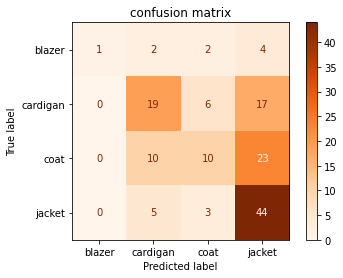

```
blazer: accuracy=11.11%
cardigan: accuracy=45.24%
coat: accuracy=23.26%
jacket: accuracy=84.62%
```

```python
matrix6 = myresnet.test(model6, test_loader)
# 印出每個類別的準確度
matrix = list(matrix6)
for i in range(4):
  print(f'{test_dataset.classes[i]}: accuracy={matrix[i][i]/sum(matrix[i])*100:.2f}%')
```

## 第五題

[output not shown]

觀察以上三種不同模型預測結果可以發現，有經過pretrained的模型具有較高的準確率、每一層權重皆有訓練的模型結果最好，上網查了相關的文章後，發現pretrained過的模型因為已經初步了解影像的資訊因此會有較快的收斂速度，而在經過這次作業後，我發現確實會有這個趨勢；此外，利用Adam optimizer的模型收斂速度似乎比較慢，但模型預測結果在兩種狀況有比較好。